# Tema 6: Otros Temas Básicos

Jorge Sosa-García

Primavera 2023

## 6.1. Reescalamiento de Variables

Reescalar datos es particularmente útil cuando, por fines estéticos, se requiere agregar o eliminar decimales. Veremos que es lo que sucede con los estimadores de MCO, sus errores estándar y sus estadísticos de prueba cuando se realizan diversos reescalamientos de las variables de un modelo.

Para las siguientes secciones consideraremos el modelo:
$$\hat{y}= \hat{\beta}_0 + \hat{\beta}_1 x_1 +
\hat{\beta}_2 x_2 + ... + \hat{\beta}_k x_k
\quad\quad\quad\quad\quad\quad\quad (1)$$
¿Que pasaría con este modelo si…

### 6.1.1. Reescalamiento de la Variable Dependiente

Se escalara la variable dependiente, $y$ al multiplicarla por una constante $c \neq 0$?

Este caso es trivial pues basta con multiplicar la ecuación (1) por la constante $c$:
$$c\hat{y}= c\hat{\beta}_0 + c\hat{\beta}_1 x_1 +
c\hat{\beta}_2 x_2 + ... + c\hat{\beta}_k x_k$$

Esto implica que:

- Cada coeficiente estimado del modelo “original” se multiplica por la constante $c$.
- Los errores estándar se multiplican por la constante $c$.
- Ningún estadístico $t$ no cambia.

### 6.1.2. Reescalamiento de la Variable Independiente

Se escalara la variable independiente, $x_j$ al multiplicarla por una constante $c \neq 0$?

Supongamos queremos multiplicar $x_1$ por $c$. Partiendo de la ecuación (1), procedemos como sigue:
$$\begin{align*}
\hat{y}&= \hat{\beta}_0 + \frac{\hat{\beta}_1}{c} (c \: x_1) +
\hat{\beta}_2 x_2 + ... + \hat{\beta}_k x_k\\
&= \hat{\beta}_0 + \frac{\hat{\beta}_1}{c} \tilde{x_1} +
\hat{\beta}_2 x_2 + ... + \hat{\beta}_k x_k
\end{align*}$$

donde $\tilde{x_1} = c\: x_1$. Esto implica que:

- El único coeficiente que cambia es el de $x_1$, que se multiplica por el inverso de $c$.
- El único error estándar que cambia es el de $x_1$, que se multiplica por el inverso de $c$.
- Ningún estadístico $t$ no cambia.

### 6.1.3. Modelos Estandarizados

Supongamos que en lugar de buscar un modelo que responda a ¿cuánto cambia $y$ ($\Delta y$) ante una *variación unitaria en $x_j$* ($\Delta x_j$)?, buscamos un modelo que responda a ¿cuánto cambia $y$ ($\Delta y$) cuando $x_j$ *varía en una desviación estándar*?

Obtener este modelo es relativamente sencillo su partimos de:
$$\:y_i = \hat{\beta}_0 + \hat{\beta}_1 x_{i1} +
\hat{\beta}_2 x_{i2} + ... + \hat{\beta}_k x_{ik} + \hat{u}_i
\quad\quad\quad\quad\quad\quad\quad\quad\quad\quad\quad\quad\quad\quad\quad\quad\quad\quad\quad
(2)$$
Si tomamos el promedio de (2) última ecuación obtenemos:
$$\:\bar{y} = \hat{\beta}_0 + \hat{\beta}_1
\bar{x_1} + \hat{\beta}_2 \bar{x_2} + ... + \hat{\beta}_k \bar{x_k}
\quad\quad\quad\quad\quad\quad\quad\quad\quad\quad\quad\quad\quad\quad\quad\quad\quad\quad\quad\quad\quad\quad
(3)$$
Restando las ecuaciones (2) y (3) tenemos:
$$y_i - \bar{y} = \hat{\beta}_1 (x_{i1} -
\bar{x_1}) + \hat{\beta}_2 (x_{i2} - \bar{x_2}) + ... + \hat{\beta}_k
(x_{ik} - \bar{x_k}) + \hat{u}_i
\quad\quad\quad\quad\quad\quad\quad\quad\quad\quad\quad (4)$$
Denotemos como $\hat{\sigma}_y$ la desviación estándar muestral de $y$ y como $\hat{\sigma}_j$ la desviación estándar muestral de $x_j$. De esta forma, de (4) obtenemos
$$\frac{y_i -
\bar{y}}{\hat{\sigma}_y} = \frac{\hat{\sigma}_1}{\hat{\sigma}_y}
\hat{\beta}_1 \frac{x_{i1} - \bar{x_1}}{\hat{\sigma}_1} +
\frac{\hat{\sigma}_2}{\hat{\sigma}_y} \hat{\beta}_2 \frac{x_{i2} -
\bar{x_2}}{\hat{\sigma}_2} + ... + \frac{\sigma_k}{\sigma_y}
\hat{\beta}_k \frac{x_{ik} - \bar{x_k}}{\hat{\sigma}_k} +
\frac{\hat{u}_i}{\hat{\sigma}_y} \quad\quad\quad\quad\quad\quad\quad
(5)$$
Notemos que en (5) cada variable ha sido estadarizada. Para simplificar la notación escribimos este modelo como
$$z_y = \hat{b_1} z_1 + \hat{b_2} z_2 + ... +
\hat{b_k} z_k + v$$
donde $\hat{b_j} = \frac{\hat{\sigma}_j}{\hat{\sigma}_y} \: \hat{\beta}_j$ para $j = 1, 2, ..., k$ y $v = \frac{u}{\hat{\sigma}_y}$

Los coeficientes $\hat{b_j}$ se llaman coeficientes beta y se interpretan como **el cambio que hay en $y$ (medido en desviaciones estándar) cuando $x_j$ incrementa en una desviación estándar**.

Observemos que cuando se estandarizan las variables, sus unidades de medición son eliminadas, por lo que las vuelve comparables entre ellas. Esto resulta particularmente útil cuando se desea encontrar la variables independiente que tiene un mayor efecto sobre la variable dependiente.

## 6.2. Formas Funcionales

Ahora discutamos como se pueden incorporar diversas formas funcionales que darán mucha más flexibilidad al modelo de regresión múltiple.

### 6.2.1. Logaritmo en $x_j$

Cuando incorporamos el *logaritmo* en la variable independiente se tiene un modelo **nivel-log**.

El modelo poblacional se expresa como:
$$y
= \beta_0 + \beta_1 x_1 + \beta_2 x_2 + ... + \beta_j \ln(x_j) +... +
\beta_k x_k + u$$
y la ecuación estimada resultante es
$$\hat{y}= \hat{\beta}_0 + \hat{\beta}_1 x_1 +
\hat{\beta}_2 x_2 + ... + \hat{\beta}_j \ln(x_j) + ... + \hat{\beta}_k
x_k$$

En este modelo la interpretación de $\hat{\beta}_j$ está dada por:
$$\begin{align*}
\Delta y &= \hat{\beta}_j \: \frac{\Delta x_j}{x_j} \\
&= \frac{\hat{\beta}_j}{100} \bigg( \frac{\Delta x_j}{x_j}
\times 100 \bigg) \\
&= \frac{\hat{\beta}_j}{100} (\Delta x_j)\%
\end{align*}$$

Esto significa que **cuando $x_j$ aumenta en 1%, $y$ cambia en $\frac{\hat{\beta}_j}{100}$ unidades**.

### 6.2.2. Logaritmo en $y$

Cuando incorporamos el *logaritmo* en la variable dependiente se tiene un modelo **log-nivel**, también llamado modelo de **semi-elasticidad**.

El modelo poblacional se expresa como:
$$\ln(y) = \beta_0 + \beta_1 x_1 + \beta_2 x_2 +
... + \beta_k x_k + u$$
y la ecuación estimada resultante es
$$\widehat{\ln(y)} = \hat{\beta}_0 +
\hat{\beta}_1 x_1 + \hat{\beta}_2 x_2 + ... + \hat{\beta}_k
x_k$$

En este modelo la interpretación de $\hat{\beta}_j$ está dada por:
$$\begin{align*}
\frac{\Delta y}{y} &= \hat{\beta}_j \: \Delta x_j \\
\frac{\Delta y}{y} \times 100 &= (100 \: \hat{\beta}_j) \: \Delta
x_j \\
(\Delta y)\% &= (100 \: \hat{\beta}_j) \: \Delta x_j
\end{align*}$$

Esto significa que **cuando $x_j$ aumenta en una unidad, $y$ cambia en $(100 \:\hat{\beta}_j)$%**.

### 6.2.3. Logaritmo en $x_j$ e $y$

Cuando incorporamos el *logaritmo* en la variable dependiente y en la variable independiente se tiene un modelo **log-log**, también llamado modelo de **elasticidad**.

El modelo poblacional se expresa como:
$$\ln(y) = \beta_0 + \beta_1 x_1 + \beta_2 x_2 +
... + \beta_j \ln(x_j) +... + \beta_k x_k + u$$
y la ecuación estimada resultante es
$$\widehat{\ln(y)} =
\hat{\beta}_0 + \hat{\beta}_1 x_1 + \hat{\beta}_2 x_2 + ... +
\hat{\beta}_j \ln(x_j) + ... + \hat{\beta}_k x_k$$

En este modelo la interpretación de $\hat{\beta}_j$ está dada por:
$$\begin{align*}
\frac{\Delta y}{y} &= \hat{\beta}_j \: \frac{\Delta x_j}{x_j} \\
\frac{\Delta y}{y} \times 100 &= \hat{\beta}_j \: \bigg(
\frac{\Delta x_j}{x_j} \times 100 \bigg) \\
(\Delta y)\% &= \hat{\beta}_j \: (\Delta x_j)\%
\end{align*}$$

Esto significa que **cuando $x_j$ aumenta en 1%, $y$ cambia en $\hat{\beta}_j$%**.

### 6.2.4. Ventajas y Limitaciones del Logaritmo

Ventajas de usar el logaritmo:

- Interpretaciones útiles de los coeficientes asociados a variables con logaritmo. En particular ya no se tiene un “efecto constante” de $x$ sobre $y$.
- El modelo que usan $\ln(y)$ como la variable dependiente se apega más a los supuestos CLM que el modelo que usa a $y$ como variable dependiente.
- Las variables estrictamente positivas suelen tener distribuciones heterocedásticas o sesgadas. Usar el logaritmo de la variable suele mitigar (o eliminar) ambos problemas.
- El logaritmo suele reducir (a veces considerablemente) el rango de las variables. Esto hace que los modelos sean menos sensibles a observaciones atípicas.

Desventajas del logaritmo:

- No se pueden usar en variables que toman valores negativos o cero.
- Al usar logaritmo en la variable dependiente, predecir el valor de $y$ es más difícil (pues el modelo estima $\ln(y)$).

Algunos criterios útiles sobre cuando usar logaritmos:

- En variables que involucran dinero es común usar logaritmos.
- En variables como población, conteos de personas u otras medidas en números enteros grandes se suele usar logaritmo.
- En variables medidas en tiempo no es recomendable usar logaritmo.
- En variables que representa una proporción o un porcentaje se puede (o no) usar logaritmos. Si se usa el logaritmo se debe ser poner cuidado en la interpretación de los coeficientes (no es lo mismo un cambio de 1% que un cambio de 1pp).

### 6.2.5. Términos Cuadráticos y Polinomiales

En los modelos también es común incorporar **términos cuadráticos** (o polinomiales de grados mayores) para capturar **efectos marginales** crecientes o decrecientes.

El caso más sencillo es el siguiente:
$$y
= \beta_0 + \beta_1 x + \beta_2 x^2 + u$$
Sobre este modelo es importante notar:

- Se incluye el término cuadrático $x^2$, pero también el lineal $x$.  
  Cuando se usan términos polinomiales de grado $q$, se deben incorporar *todos* los términos de los grados menores.
- En estos modelos $\beta_j$ no mide la magnitud del cambio en $y$ con respecto de $x_j$, ya que no tiene sentido dejar fijo $x^q$ mientras se cambia $x$.

En estos casos, la ecuación estimada
$$\hat{y}= \hat{\beta}_0 + \hat{\beta}_1 x +
\hat{\beta}_2 x^2$$
sugiere que el efecto (aproximado) de $x$ sobre $y$ está dado por:
$$\Delta \hat{y}\approx (\hat{\beta}_1 + 2
\hat{\beta}_2) \Delta x \quad \rightarrow \quad \frac{\Delta
\hat{y}}{\Delta x} \approx \hat{\beta}_1 + 2 \hat{\beta}_2x$$

La utilidad de los términos cuadráticos es que permiten identificar efectos diferenciados según la magnitud de $x$. En particular un modelo cuadrático implica la existencia de un punto donde $x$ tiene un efecto cero sobre $y$. Antes de ese nivel, $x$ puede tener un efecto positivo/negativo sobre $y$, mientras que después de ese nivel $x$ tiene un efecto negativo/positivo sobre $y$.

El punto en que $x$ tiene un efecto cero sobre $y$ está dado por:
$$x^* = \bigg|
\frac{\hat{\beta}_1}{2\hat{\beta}_2} \bigg|$$
Sabiendo esto, se dice que:

- Si $\hat{\beta}_1 > 0$ y $\hat{\beta}_2 < 0$:  
  Se dice que **$x$ tiene un efecto marginal decreciente sobre $y$**.
- Si $\hat{\beta}_1 < 0$ y $\hat{\beta}_2 > 0$:  
  Se dice que **$x$ tiene un efecto marginal creciente sobre $y$**.

## 6.3. Bondad de Ajuste y Selección de Regresores

Recordemos que la $R^2$ captura cuánto de la variación de $y$ es explicada por las variables explicativas $x_1, x_2, ..., x_j$. En ese sentido la única restricción numérica que tiene el coeficiente de determinación es que está entre cero y uno.

Teniendo esto en cuenta ahora podemos ampliar la definición y utilidad de este coeficiente de determinación.

### 6.3.1. Coeficiente de Determinación Ajustado

El coeficiente de determinación se puede expresar como
$$R^2 = 1 - \bigg( \frac{SSR}{n} \bigg) \bigg/
\bigg( \frac{SST}{n} \bigg) = 1 -
\frac{\sigma^2_u}{\sigma^2_y}$$

donde $\sigma^2_u$ es la varianza poblacional de $u$ y $\sigma^2_y$ es la varianza poblacional de $y$.

En la última expresión se está estimado $\sigma^2_u$ con $SSR / n$ y $\sigma^2_y$ con $SSRT / n$. Resulta que estas estimaciones son sesgadas. Si quisiéramos usar estimadores insesgados la expresión quedaría como
$$\bar{R}^2 = 1 -
\frac{SSR}{n-k-1} \bigg/ \frac{SST}{n-1} = 1 - \frac{\hat{\sigma}^2}{SST
/ (n-1)}$$

a esta expresión se le conoce como **$R^2$ ajustada**.

La ventaja de la $R^2$ ajustada es que impone un “castigo” por incorporar variables explicativas al modelo: mientras la $R^2$ convencional nunca disminuye (y por lo general aumenta) al incorporar un nuevo regresor, la $r^2$ ajustada depende (explícitamente) del número de regresores $k$ usados. Al agregar una nueva variable independiente $SSR$ disminuye, pero también lo hace los grados de libertad $n-k-1$.

## 6.4. Ejemplos

Veamos algunos ejemplos de los conceptos cubiertos.

### 6.4.1. Escalado de Datos

Consideremos una pregunta simple: ¿cuál es el efecto que tiene fumar durante el embarazo sobre el peso del bebé recién nacido?

Para explorar esta pregunta, además del número de cigarros fumados (`cigs`) y el peso del bebé recién nacido (`bwght`), también consideraremos al ingreso familiar (`faminc`) y el impuesto que se cobra a los cigarros (`cigtax`) como variables explicativas.

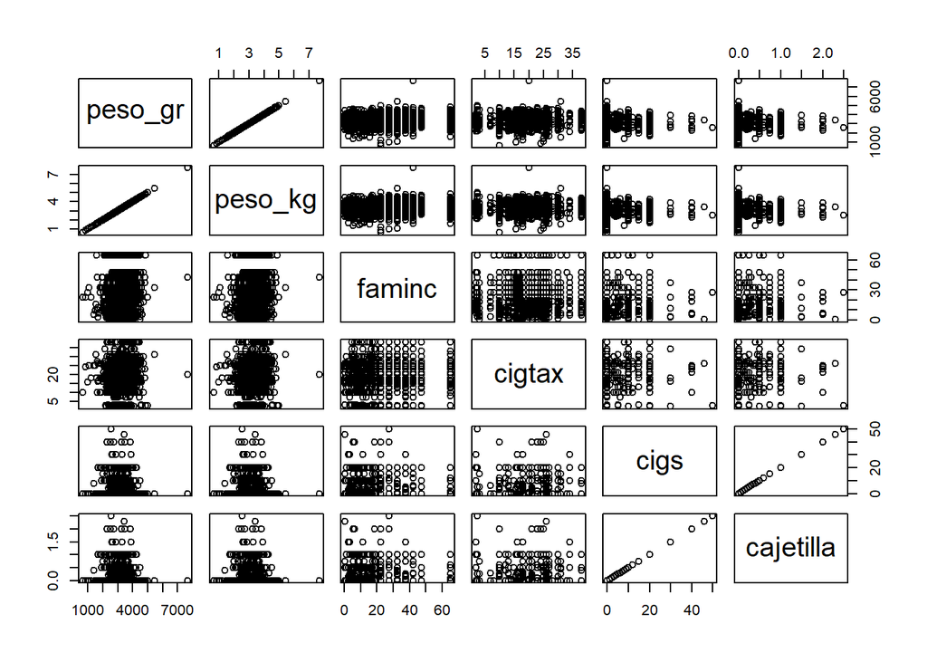

```r
# Carga de base de datos
data(bwght)

# Definicion y seleccion de variables relevantes
base1 <- bwght %>%
    mutate(peso_gr = bwght * 28.34952,
           peso_kg = peso_gr / 1000,
           cajetilla = cigs / 20) %>%
    select(peso_gr, peso_kg, faminc, cigtax, cigs, cajetilla)

# Grafica
plot(base1)
```

En la gráfica observamos que, dada las definiciones que hicimos de las variables, existen relaciones lineales exactas entre varias de ellas. Para no violar RLM4 es importante no usar estas variables (explicativas) en un mismo modelo.

```r
# Definicion modelos
modelo_peso_1 <- lm(formula = peso_gr ~ faminc + cigtax + cigs,
                    data = base1)
modelo_peso_2 <- lm(formula = peso_gr ~ faminc + cigtax + cajetilla,
                    data = base1)
modelo_peso_3 <- lm(formula = peso_kg ~ faminc + cigtax + cigs,
                    data = base1)
modelo_peso_4 <- lm(formula = peso_kg ~ faminc + cigtax + cajetilla,
                    data = base1)

# Presentacion de resultados
stargazer(modelo_peso_1, modelo_peso_2,
          modelo_peso_3, modelo_peso_4,
          digits = 3, type = "text", style = "qje",
          report = c("vc*st"),
          dep.var.labels = c("Peso en GR", "Peso en KG"),
          covariate.labels = c("Ingreso Familiar",
                               "Impuestos",
                               "Cigarros",
                               "Cajetillas",
                               "Constante"))
```

```
##
## ===============================================================================
##                                        Peso en GR              Peso en KG
##                                     (1)          (2)         (3)        (4)
## -------------------------------------------------------------------------------
## Ingreso Familiar                  2.593***     2.593***    0.003***   0.003***
##                                   (0.827)      (0.827)     (0.001)    (0.001)
##                                  t = 3.136    t = 3.136   t = 3.136  t = 3.136
##
## Impuestos                          3.726*       3.726*      0.004*     0.004*
##                                   (1.959)      (1.959)     (0.002)    (0.002)
##                                  t = 1.902    t = 1.902   t = 1.902  t = 1.902
##
## Cigarros                         -13.300***               -0.013***
##                                   (2.595)                  (0.003)
##                                  t = -5.125               t = -5.125
##
## Cajetillas                                   -266.002***             -0.266***
##                                                (51.902)               (0.052)
##                                               t = -5.125             t = -5.125
##
## Constante                       3,244.721*** 3,244.721***  3.245***   3.245***
##                                   (47.887)     (47.887)    (0.048)    (0.048)
##                                  t = 67.757   t = 67.757  t = 67.757 t = 67.757
##
## N                                  1,388        1,388       1,388      1,388
## R2                                 0.032        0.032       0.032      0.032
## Adjusted R2                        0.030        0.030       0.030      0.030
## Residual Std. Error (df = 1384)   568.234      568.234      0.568      0.568
## F Statistic (df = 3; 1384)       15.415***    15.415***   15.415***  15.415***
## ===============================================================================
## Notes:                                   ***Significant at the 1 percent level.
##                                           **Significant at the 5 percent level.
##                                           *Significant at the 10 percent level.
```

La tabla muestra resultados consistentes con los reescalamientos hechos:

- Los coeficientes y errores estándar de la variable `cajetilla` son 20 veces mayores que los de la variable `cigs`.
- Los coeficientes y errores estándar de los modelos que usan `peso_kg` como variable a explicar son 1,000 veces menores a los de los modelos que usan `peso_gr` como variable a explicar.

En ese sentido, todos los modelos tienen los mismos efectos y las mismas implicaciones por lo que la elección del modelo se limita simplemente a temas estéticos y/o de conveniencia en la lectura de resultados.

### 6.4.2. Estandarización de Datos

Tenemos información sobre las características de las casas en diversos vecindarios y queremos determinar cuál es su efecto sobre el precio de las mismas. En particular nos interesa saber cuál es el factor que mayor influencia tiene sobre el precio de las casas, por lo qu usaremos un modelo estabdarizado (beta).

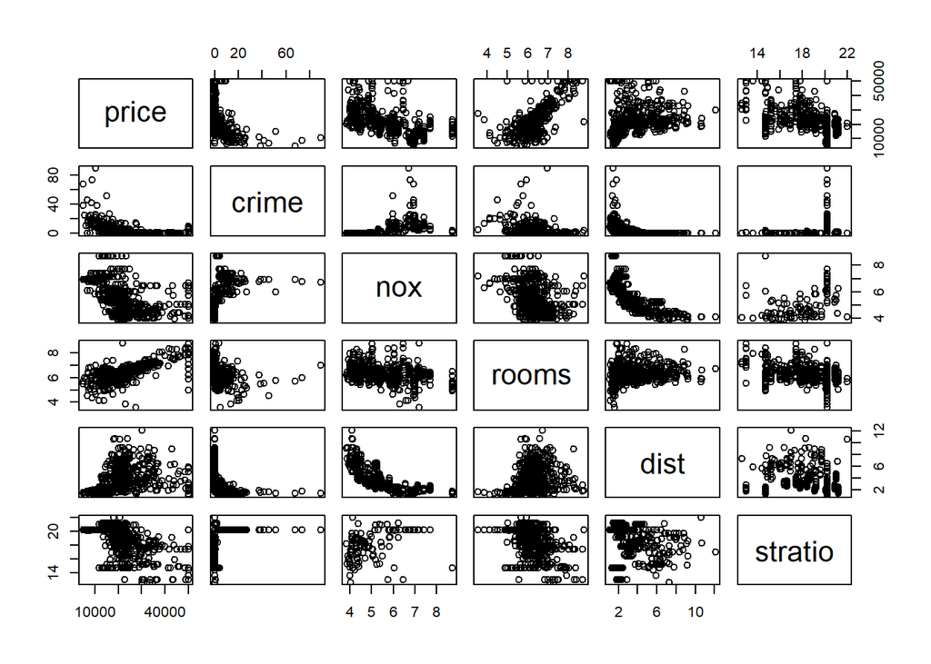

```r
# Carga datos
data(hprice2)

# Seleccion de variables relevantes
base2 <- hprice2 %>%
    select(price, crime, nox, rooms, dist, stratio)

# Grafica
plot(base2)
```

```r
# Modelo de niveles
modelo_base <- lm(formula = price ~ crime  + nox + rooms + dist + stratio,
                  data = base2)

# Modelo estandarizado
modelo_precio_casas <- lm(formula = scale(price) ~ 0 + scale(crime) + scale(nox) +
                              scale(rooms) + scale(dist) + scale(stratio),
                          data = base2)

# Presentacion resultados
stargazer(modelo_base, modelo_precio_casas, digits = 3,
          type = "text", style = "io",
          dep.var.labels = c("Precio (lvl)", "Precio (beta)"),
          covariate.labels = c("Crimen", "Contaminación",
                               "Cuartos", "Distancia",
                               "Docente/Alumnado",
                               "Crimen STD", "Contaminación STD",
                               "Cuartos STD", "Distancia STD",
                               "Docente/Alumnado STD",
                               "Constante"))
```

```
##
## -------------------------------------------------------------------------
##                               Precio (lvl)            Precio (beta)
##                                   (1)                      (2)
## -------------------------------------------------------------------------
## Crimen                        -153.601***
##                                 (32.929)
## Contaminación                -2,706.433***
##                                (354.087)
## Cuartos                       6,735.498***
##                                (393.604)
## Distancia                    -1,026.806***
##                                (188.108)
## Docente/Alumnado             -1,149.204***
##                                (127.429)
## Crimen STD                                              -0.143***
##                                                          (0.031)
## Contaminación STD                                       -0.340***
##                                                          (0.044)
## Cuartos STD                                              0.514***
##                                                          (0.030)
## Distancia STD                                           -0.235***
##                                                          (0.043)
## Docente/Alumnado STD                                    -0.270***
##                                                          (0.030)
## Constante                    20,871.130***
##                               (5,054.599)
## Observations                      506                      506
## R-squared                        0.636                    0.636
## Adjusted R-squared               0.632                    0.632
## Residual standard error   5,586.198 (df = 500)       0.606 (df = 501)
## F statistic             174.473*** (df = 5; 500) 174.822*** (df = 5; 501)
## -------------------------------------------------------------------------
## Notes:                  ***p < .01; **p < .05; *p < .1
```

Algunas cosas importantes que notar de estos resultados:

- Las magnitudes de los coeficientes estimados son muy distintas.
- El modelo estandarizado no tiene intercepto.
- La significancia estadística de los coeficientes no cambia del modelo de niveles al modelo estandarizado.

¿Cómo se interpretarían los resultados para el modelo de niveles?

- `crime`: ante un incremento de 1 crimen per cápita, el precio de la casa cambia en $-153.601USD.
- `nox`: cando la contaminación incrementa en 1pp100m, el precio de la casa cambia en $-2,706.433USD.

### 6.4.3. Formas Logarítmicas

Retomemos el modelo que pretende explicar el efecto de la contaminación sobre el precio de una casa.

Veremos cuatro variantes de este modelo: modelo level-level, modelo level-log, modelo log-level y modelo log-log.

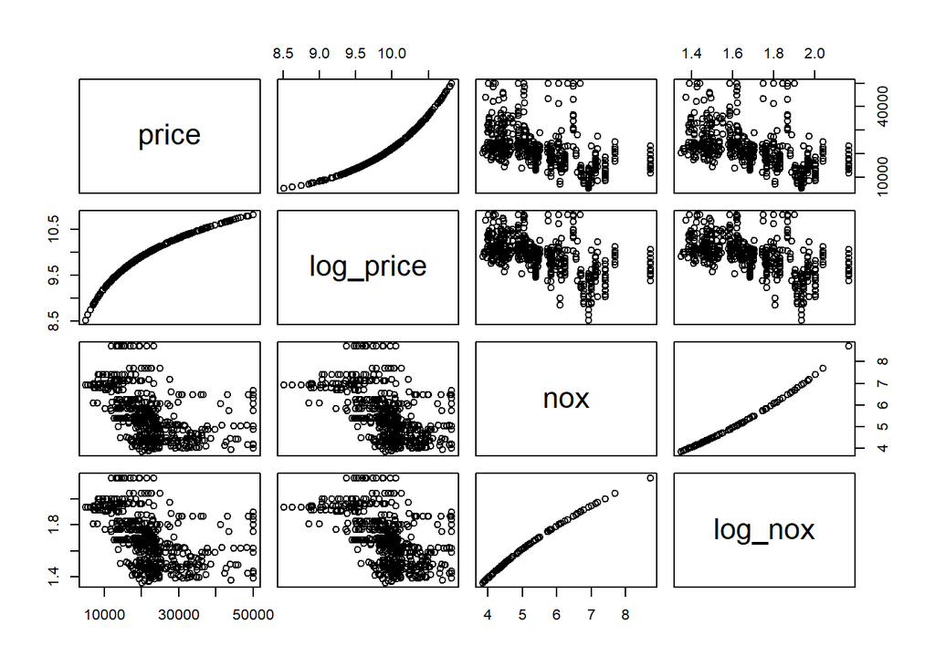

```r
# Carga bases
data(hprice2)

# Seleccion de variables relevantes
base3 <- hprice2 %>%
    mutate(log_price = log(price),
           log_nox = log(nox)) %>%
    select(price, log_price, nox, log_nox)

# Grafica
plot(base3)
```

```r
# Modelos
modelo_lvl_lvl <- lm(formula = price ~ nox,
                     data = base3)
modelo_lvl_log <- lm(formula = price ~ log_nox,
                     data = base3)
modelo_log_lvl <- lm(formula = log_price ~ nox,
                     data = base3)
modelo_log_log <- lm(formula = log_price ~ log_nox,
                     data = base3)

# Presentacion resultados
stargazer(modelo_lvl_lvl, modelo_lvl_log,
          modelo_log_lvl, modelo_log_log,
          digits = 3, type = "text", style = "io",
          dep.var.labels = c("Precio",
                             "LOG(Precio)"),
          covariate.labels = c("Contaminación",
                               "LOG(Contaminación)",
                               "Constante"))
```

```
##
## -------------------------------------------------------------------------------------
##                                               Precio                 LOG(Precio)
##                                         (1)           (2)          (3)        (4)
## -------------------------------------------------------------------------------------
## Contaminación                      -3,386.853***                -0.180***
##                                      (320.362)                   (0.014)
## LOG(Contaminación)                               -19,635.130***            -1.043***
##                                                   (1,839.252)               (0.078)
## Constante                          41,307.810*** 55,755.580***  10.939***  11.707***
##                                     (1,816.182)   (3,135.934)    (0.077)    (0.132)
## Observations                            506           506          506        506
## R-squared                              0.182         0.184        0.259      0.264
## Adjusted R-squared                     0.180         0.183        0.257      0.262
## Residual standard error (df = 504)   8,339.566     8,324.692      0.353      0.352
## F statistic (df = 1; 504)           111.766***     113.969***   176.019*** 180.364***
## -------------------------------------------------------------------------------------
## Notes:                             ***p < .01; **p < .05; *p < .1
```

La representación gráfica de estos modelos es muy parecida entre ellos (observemos los cambios en las escalas de los ejes):

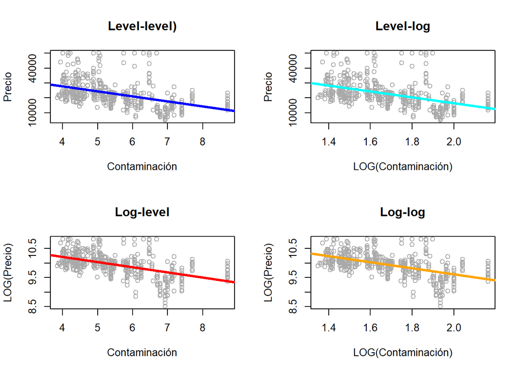

```r
# Cuadricula 2x2
par(mfrow = c(2, 2))

# Grafica lvl-lvl
with(base3,
     plot(nox, price, col = "dark gray",
          main = "Level-level)",
          xlab = "Contaminación",
          ylab = "Precio"))
abline(modelo_lvl_lvl, col = "blue", lwd = 3)

# Grafica lvl-log
with(base3,
     plot(log(nox), price, col = "dark gray",
          main = "Level-log",
          xlab = "LOG(Contaminación)",
          ylab = "Precio"))
abline(modelo_lvl_log, col = "cyan", lwd = 3)

# Grafica log-lvl
with(base3,
     plot(nox, log(price), col = "dark gray",
          main = "Log-level",
          xlab = "Contaminación",
          ylab = "LOG(Precio)"))
abline(modelo_log_lvl, col = "red", lwd = 3)

# Grafica log-log
with(base3,
     plot(log(nox), log(price), col = "dark gray",
          main = "Log-log",
          xlab = "LOG(Contaminación)",
     ylab = "LOG(Precio)"))
abline(modelo_log_log, col = "orange", lwd = 3)
```

### 6.4.4. Formas Cuadráticas

Consideremos el efecto que tiene la experiencia sobre los salarios.

La intuición sugiere que entre mayor experiencia se tenga, mayor será el salario percibido. Sin embargo también es posible que un “exceso” de experiencia pueda tener un efecto negativo sobre el salario (¿por qué?).

Para explorar esta posibilidad, usando los datos en `wage1` estimamos un modelo que incluya un término cuadrático de la experiencia:
$$wage = \beta_0 + \beta_1
\: exper + \beta_2 \: exper^2 + u$$

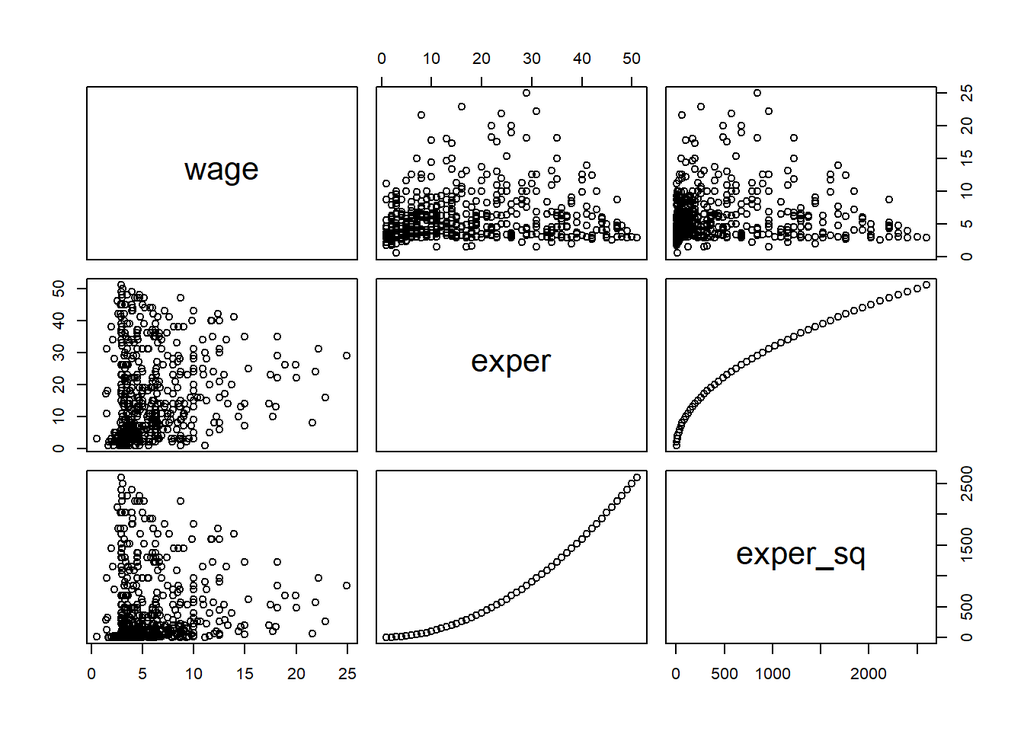

```r
# Carga de datos
data(wage1)

# Selección de variables relevantes
base4 <- wage1 %>%
  mutate(exper_sq = exper^2) %>%
  select(wage, exper, exper_sq)

# Grafica de variables
plot(base4)
```

```r
# Estimacion del modelo
modelo_experiencia <- lm(formula = wage ~ exper + exper_sq,
                         data = base4)

# Presentacion de resultados
stargazer(modelo_experiencia, digits = 3,
          type = "text", style = "qje",
          dep.var.labels = c("Salario"),
          covariate.labels = c("Experiencia",
                               "Esperancia SQ",
                               "Constante"))
```

```
##
## ==========================================================
##                                    Salario
## ----------------------------------------------------------
## Experiencia                        0.298***
##                                    (0.041)
##
## Esperancia SQ                     -0.006***
##                                    (0.001)
##
## Constante                          3.725***
##                                    (0.346)
##
## N                                    526
## R2                                  0.093
## Adjusted R2                         0.089
## Residual Std. Error            3.524 (df = 523)
## F Statistic                26.740*** (df = 2; 523)
## ==========================================================
## Notes:              ***Significant at the 1 percent level.
##                      **Significant at the 5 percent level.
##                      *Significant at the 10 percent level.
```

Los resultados obtenidos indican que existe un efecto marginal decreciente para la experiencia. Para poder ahondar más en estos retornos decrecientes necesitamos calcular el punto de quiebre (donde `exper` tiene efecto cero sobre el salario). Esto se hace de la siguiente manera:
$$x^* = \bigg|
\frac{\hat{\beta}_1}{2 \hat{\beta}_2} \bigg| = \bigg| \frac{0.298}{2
(-0.006)} \bigg| = 24.315$$
Esto indica que:

- Quienes tienen menos de 24.315 años de experiencia reciben un efecto positivo por cada año adicional de experiencia.
- Quienes tienen más de 24.315 años de experiencia reciben un efecto negativo por cada año adicional de experiencia.

Este efecto marginal es más facil de apreciar con la representación gráfica del modelo:

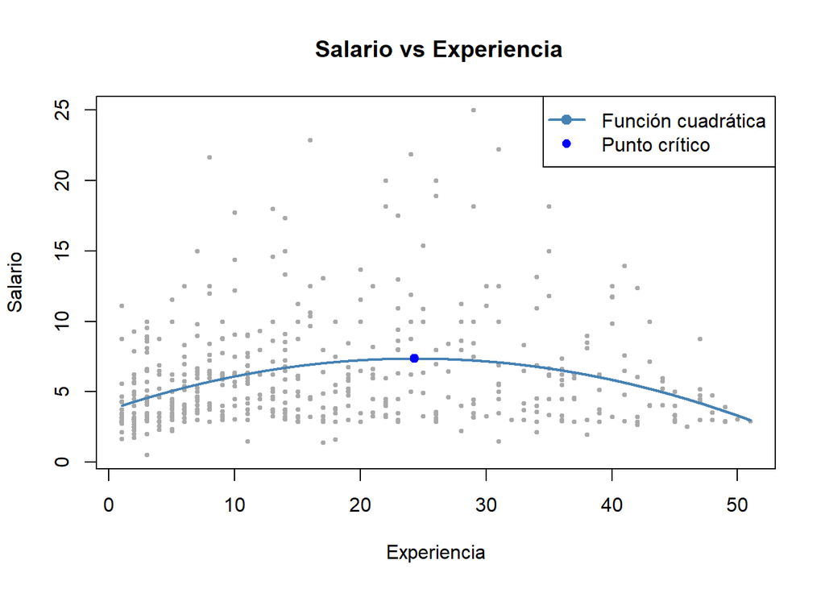

```r
# Identificacions de coeficientes
b_0 <- coef(modelo_experiencia)[1]
b_1 <- coef(modelo_experiencia)[2]
b_2 <- coef(modelo_experiencia)[3]

# Calculo del punto de quiebre
x <- abs(b_1 / (2 * b_2))
y <- b_0 + b_1 * x + b_2 * x^2

# Generación de valores para grafica cuadratica
x_val <- with(base4,
              seq(min(exper), max(exper), 0.01))

# Grafica de puntos
with(base4,
     plot(exper, wage,
          col = "dark gray",
          pch = 19, cex = 0.50,
          main = " Salario vs Experiencia",
          xlab = "Experiencia",
          ylab = "Salario"))

# Grafica cuadratica
lines(x_val, b_0 + b_1 * x_val + b_2 * x_val^2,
      col = "steel blue", lwd = 2)

# Grafica punto de quiebre
with(base4,
     points(x, y, type = "p", pch = 19, col = "blue"))

# Legend
legend(x = "topright",
       lty = c(1, 0),
       lwd = c(2, 0),
       pch = c(NULL, 19),
       col = c("steel blue", "blue"),
       legend = c("Función cuadrática",
                  "Punto crítico"))
```

- Siendo todo lo demás igual, una persona que pasa de 5 a 6 años de experiencia incrementará su salario en $0.24USD.
- Siendo todo lo demás igual, una persona que pasa de 23 a 24 años de experiencia incrementará su salario en $0.02USD.
- Siendo todo lo demás igual, una persona que pasa de 25 a 26 años de experiencia disminuirá su salario en $-0.01USD.
- Siendo todo lo demás igual, una persona que pasa de 40 a 41 años de experiencia disminuirá su salario en $-0.19USD.

### 6.4.5. $\bar{R^2}$ para Selección de Modelos

Vamos a revisar nuestro modelo del salario de los jugadores de baseball con algunas modificaciones. Ahora nuestro objetivo es seleccionar el modelo que nos permita entender de manera más completa los determinantes salariales de la MLB.

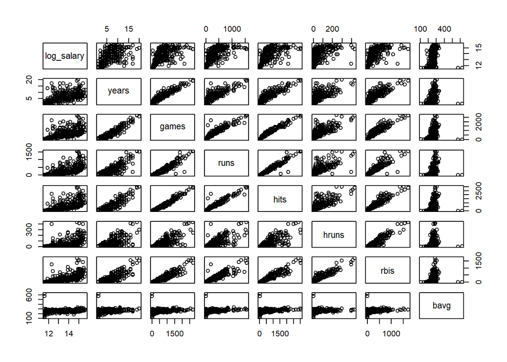

```r
# Carga de datos
data(mlb1)

# Selección de variables relevantes
base5 <- mlb1 %>%
  mutate(log_salary = log(salary)) %>%
  select(log_salary, years, games, runs, hits, hruns, rbis, bavg)

# Grafica de variables
plot(base5)
```

```r
# Estimacion de los modelos
modelo_base1 <- lm(formula = log_salary ~ years + games + runs + hits + hruns + rbis + bavg,
                   data = base5)
modelo_base2 <- lm(formula = log_salary ~ games + runs + hits + bavg,
                   data = base5)
modelo_base3 <- lm(formula = log_salary ~ games + runs + bavg,
                   data = base5)

# Presentacion de resultados
stargazer(modelo_base1,
          modelo_base2,
          modelo_base3,
          digits = 3,
          type = "text", style = "qje",
          dep.var.labels = c("Log(Salario)"),
          covariate.labels = c("Antigüedad",
                               "Juegos",
                               "Carreras",
                               "Hits",
                               "Home Runs",
                               "Carreras Impulsadas",
                               "Promedio Bateo",
                               "Constante"))
```

```
##
## ===========================================================================================
##                                                  Log(Salario)
##                               (1)                     (2)                     (3)
## -------------------------------------------------------------------------------------------
## Antigüedad                  -0.064
##                             (0.042)
##
## Juegos                     0.002***                0.001***                 0.001**
##                             (0.001)                (0.0004)                (0.0002)
##
## Carreras                   0.002***                0.002***                0.001***
##                             (0.001)                 (0.001)                (0.0005)
##
## Hits                       -0.002***                -0.001
##                             (0.001)                 (0.001)
##
## Home Runs                   -0.001
##                             (0.003)
##
## Carreras Impulsadas          0.002
##                             (0.001)
##
## Promedio Bateo             0.004***                 0.003**                 0.003**
##                             (0.001)                 (0.001)                 (0.001)
##
## Constante                  11.814***               11.758***               11.931***
##                             (0.348)                 (0.345)                 (0.329)
##
## N                             353                     353                     353
## R2                           0.477                   0.461                   0.457
## Adjusted R2                  0.466                   0.455                   0.452
## Residual Std. Error    0.864 (df = 345)        0.873 (df = 348)        0.875 (df = 349)
## F Statistic         44.924*** (df = 7; 345) 74.320*** (df = 4; 348) 97.751*** (df = 3; 349)
## ===========================================================================================
## Notes:                                               ***Significant at the 1 percent level.
##                                                       **Significant at the 5 percent level.
##                                                       *Significant at the 10 percent level.
```

De la tabla de resultados es importante notar que:

- La $R^2$ de los modelos es mayor en aquellos que incluyen más variables explicativas. Esto hace que el coeficiente de determinación sea una mala herramienta para decidir si una variable pertenece al modelo o no.
- La $\bar{R}^2$ es una mejor herramienta (aunque no ideal) para elegir entre diversos modelos. En este caso el modelo 81) es el que tiene mayor capacidad para explicar el salario de los jugadores.
- Es importante recordar que el criterio principal para decidir si una variable(s) pertenece(n) a un modelo es si significancia (conjunta) sobre la variable a explicar.

## 6.5. Ejercicios

1. Sean $\hat{\beta}_0, \hat{\beta}_1, \hat{\beta}_2, ..., \hat{\beta}_k$ los estimadores de MCO resultantes de la regresión de $y$ en $x_1, x_2, ..., x_k$.
   Sean $c_0, c_1, c_2, ..., c_k$ constantes diferentes (todas) de cero. Demuestre que los estimadores de MCO de la regresión de $c_0y$ en $c_1 x_1, c_2 x_2, ..., c_k x_k$ están dados por:
   $$\tilde{\beta_0} = c_0
   \hat{\beta}_0, \quad \tilde{\beta_1} = \frac{c_0}{c_1} \hat{\beta}_2,
   \quad \tilde{\beta_2} = \frac{c_0}{c_2} \hat{\beta}_2, \quad ..., \quad
   \tilde{\beta_k} = \frac{c_0}{c_k} \hat{\beta}_2$$
2. Considere la base de datos `401k` para estimar los siguientes modelos:
   $$\begin{align*}
   prate &= \beta_0 + \beta_1 mrate + \beta_2 age + \beta_3 totemp +
   u\\
   prate &= \beta_0 + \beta_1 mrate + \beta_2 age + \beta_3 \ln(totemp)
   + u \\
   prate &= \beta_0 + \beta_1 mrate + \beta_2 age + \beta_3 totemp +
   \beta_4 totemp^2 + u
   \end{align*}$$
   ¿Cuál modelo prefiere? ¿Por qué?
3. Considere la base de datos `gpa2`.
   1. Estime el modelo
      $$sat = \beta_0 +
      \beta_1 hsize + \beta_2 hsize^2 + u$$
      Presente los resultados en forma de tabal. ¿el término cuadrático es estadísticamente significativo?
   2. Usando la ecuación estimada, ¿cuál es el tamaño “ideal” de preparatoria? Justifique su respuesta.
   3. Encuentre el tamaño “ideal” de la preparatoria usando $\ln(sat)$ como variable dependiente.  
      ¿Cambia mucho la resuesta con respecto al inciso anterior?